# Activity 11 - Linear Regression

Jae Salazar

2026-07-05

## Load all libraries.

```r
library(sf)
library(terra)
library(dplyr)
```

# Simple linear regression

## 2. Read in the species data and remove unnecessary rows with NAs.

```r
herpedata <- data.frame(read.csv("D:/Files/DLSU Files/Year 3 Term 3/LBBBI27/Activity 3/herpetozoa-033-095-s001.csv"))
cleaningdata <- complete.cases(herpedata)
herpeclean <- herpedata[cleaningdata, ]
```

## 3. Read in the elevation data (ph_strm_geo.tif).

```r
phil_dem <- rast("D:/Files/DLSU Files/Year 3 Term 3/LBBBI27/Activity 10/ph_ strm_geo.tif")
```

## 4. From the species data, subset the longitude and latitude coordinates. Then convert the coordinates to a spatial vector using the “vect” function from the “terra” package.

```r
herpecoord <- herpeclean[2:3]
coord <- vect(herpecoord)
```

## 5. Using the converted coordinates, extract elevation data for each point with the “extract” function in the “terra” package. The extracted data will have two columns: “ID” and “Band_1.” The “Band_1” column contains the elevation.

```r
coordelev <- extract(phil_dem, coord)
```

## 6. Subset the species data to retain only the species richness column (SPPTotal). Then combine this column with the extracted elevation. Rename “Band_1” to “elevation.”

```r
richness <- herpeclean$SPPTotal
richelev <- cbind(richness, coordelev$Band_1)
colnames(richelev) <- c("Richness", "Elevation")
richelev <- as.data.frame(richelev)
richelev
```

```
##    Richness Elevation
## 1         0       276
## 2         0       215
## 3         0       189
## 4         0       105
## 5         1       662
## 6         1       754
## 7         1       814
## 8         1      1020
## 9         1       474
## 10        1       439
## 11        1       517
## 12        1       561
## 13        1       686
## 14        1       797
```

[output cut: 35 more lines]

## 7. Now, perform simple linear regression using the code from the pre-lab lecture, including a plot. What can you infer about the relationship between species and elevation?

```r
x <- richelev$Elevation
y <- richelev$Richness
xbar <- mean(x)
ybar <- mean(y)
b <- sum((x - xbar) * (y - ybar)) / sum((x - xbar)^2)
a <- ybar - b * xbar
cat("Regression Equation:\n")
```

```
## Regression Equation:
```

```r
cat("y=", round(a,3), "+", round(b,3), "x\n")
```

```
## y= 4.176 + -0.004 x
```

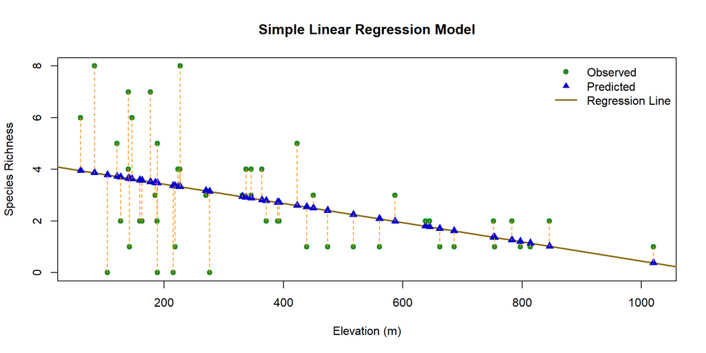

```r
yhat <- a + b * x
plot(x, y,
  pch = 19,
  col = "forestgreen",
  xlab = "Elevation (m)",
  ylab = "Species Richness",
  main = "Simple Linear Regression Model")
abline(a, b, col = "goldenrod4", lwd = 2)
points(x, yhat, pch = 17, col = "mediumblue", cex = 1.2)
segments (x0 = x, y0 = y, x1 = x, y1 = yhat, lty = 2, col = "darkorange")
legend("topright",
  legend = c("Observed", "Predicted", "Regression Line"),
  pch = c(19, 17, NA),
  lty = c(NA, NA, 1),
  col = c("forestgreen", "mediumblue",  "goldenrod4"),
  lwd = c(NA, NA, 2),
  bty = "n")
```

While the observed values seem to be more spread out across elevations, the best fitted line predicts that species richness increases as elevation decreases.

# B. Multiple linear regression

## 1. Read in both annual precipitation and temperature data and extract the data following the instructions from A4–5.

```r
phil_rain <- rast("D:/Files/DLSU Files/Year 3 Term 3/LBBBI27/Activity 11/annual_precipitation.tif")
phil_temp <- rast("D:/Files/DLSU Files/Year 3 Term 3/LBBBI27/Activity 11/annual_temperature.tif")
coordrain <- extract(phil_rain, coord)
coordtemp <- extract(phil_temp, coord)
```

## 2. Combine the extracted data with the species and elevation data into a single dataframe.

```r
combined <- cbind(richness, coordelev$Band_1, coordrain$annual_precipitation, coordtemp$annual_temperature)
colnames(combined) <- c("Richness", "Elevation", "Annual Precipitation", "Annual Temperature")
combined <- as.data.frame(combined)
```

## 3. Perform multiple linear regression using the “lm” function.

```r
x <- combined$Elevation
x1 <- combined$`Annual Precipitation`
x2 <- combined$`Annual Temperature`
y <- combined$Richness
model <- lm(y ~ x + x1 + x2)
coef(model)
```

```
##  (Intercept)            x           x1           x2
## 76.724668071 -0.003624483 -0.021655249 -1.397486338
```

```r
a <- coef(model)[1]
b <- coef(model)[2]
c <- coef(model)[3]
d <- coef(model)[4]
cat("Regression Equation:\n")
```

```
## Regression Equation:
```

```r
cat("y=", round(a,3), "+", round(b,3), "x", "+", round(c,3), "x1", "+", round(d,3), "x2\n\n")
```

```
## y= 76.725 + -0.004 x + -0.022 x1 + -1.397 x2
```

```r
yhat <- predict(model)
residuals <- residuals(model)
results <- data.frame(
  Elevation = x,
  "Annual Precipitation" = x1,
  "Annual Temperature" = x2,
  Observed = y,
  Predicted = round(yhat,2),
  Residual = round(residuals,2)
)
print(results)
```

```
##    Elevation Annual.Precipitation Annual.Temperature Observed Predicted
## 1        276                 1714           26.23333        0      1.95
## 2        215                 1714           26.23333        0      2.17
## 3        189                 1678           26.98750        0      1.99
## 4        105                 1678           26.98750        0      2.29
## 5        662                 1788           24.94583        1      0.74
## 6        754                 1788           24.94583        1      0.41
## 7        814                 1771           25.11667        1      0.32
## 8       1020                 1883           22.57500        1      0.70
## 9        474                 1780           24.18333        1      2.66
## 10       439                 1684           25.43750        1      3.12
## 11       517                 1684           25.43750        1      2.83
## 12       561                 1734           24.69167        1      2.63
## 13       686                 1754           24.42500        1      2.12
## 14       797                 1803           23.60000        1      1.81
```

[output cut: 85 more lines]

```r
summary(model)
```

```
##
## Call:
## lm(formula = y ~ x + x1 + x2)
##
## Residuals:
##     Min      1Q  Median      3Q     Max
## -2.9599 -1.1531 -0.0372  0.6773  5.8759
##
## Coefficients:
##              Estimate Std. Error t value Pr(>|t|)
## (Intercept) 76.724668  26.354033   2.911  0.00558 **
## x           -0.003624   0.002970  -1.221  0.22863
## x1          -0.021655   0.009518  -2.275  0.02770 *
## x2          -1.397486   0.627803  -2.226  0.03107 *
## ---
## Signif. codes:  0 '***' 0.001 '**' 0.01 '*' 0.05 '.' 0.1 ' ' 1
##
## Residual standard error: 1.801 on 45 degrees of freedom
## Multiple R-squared:  0.3084, Adjusted R-squared:  0.2623
## F-statistic: 6.689 on 3 and 45 DF,  p-value: 0.0007873
```

The computed model shows that **the annual precipitation and annual temperature readings had significance levels of less than 0.05.** Thus, **these variables showed statistical significance in predicting the levels of species richness.**